# project_benoit_clemenceau

```r
if (!require(dplyr)) {
  install.packages("dplyr")
  library(dplyr)
}
```

```r
if (!require(ggplot2)) {
  install.packages("ggplot2")
  library(ggplot2)
}
if (!require(tidyverse)) {
  install.packages("tidyverse")
  library(tidyverse)
}
if (!require(broom)) {
  install.packages("broom")
  library(broom)
}
if (!require(GGally)) {
  install.packages("GGally")
  library(GGally)
}
if (!require(aod)) {
  install.packages("aod")
  library(aod)
}
if (!require(pROC)) {
  install.packages("pROC")
  library(pROC)
}
titanic = read.csv(file = "titanic/train.csv")
head(titanic)
```

```
##   PassengerId Survived Pclass
## 1           1        0      3
## 2           2        1      1
## 3           3        1      3
## 4           4        1      1
## 5           5        0      3
## 6           6        0      3
##                                                  Name    Sex Age SibSp Parch
## 1                             Braund, Mr. Owen Harris   male  22     1     0
## 2 Cumings, Mrs. John Bradley (Florence Briggs Thayer) female  38     1     0
## 3                              Heikkinen, Miss. Laina female  26     0     0
## 4        Futrelle, Mrs. Jacques Heath (Lily May Peel) female  35     1     0
## 5                            Allen, Mr. William Henry   male  35     0     0
## 6                                    Moran, Mr. James   male  NA     0     0
##             Ticket    Fare Cabin Embarked
## 1        A/5 21171  7.2500              S
## 2         PC 17599 71.2833   C85        C
## 3 STON/O2. 3101282  7.9250              S
## 4           113803 53.1000  C123        S
## 5           373450  8.0500              S
## 6           330877  8.4583              Q
```

```r
summary(titanic)
```

```
##   PassengerId       Survived          Pclass          Name
##  Min.   :  1.0   Min.   :0.0000   Min.   :1.000   Length:891
##  1st Qu.:223.5   1st Qu.:0.0000   1st Qu.:2.000   Class :character
##  Median :446.0   Median :0.0000   Median :3.000   Mode  :character
##  Mean   :446.0   Mean   :0.3838   Mean   :2.309
##  3rd Qu.:668.5   3rd Qu.:1.0000   3rd Qu.:3.000
##  Max.   :891.0   Max.   :1.0000   Max.   :3.000
##
##      Sex                 Age            SibSp           Parch
##  Length:891         Min.   : 0.42   Min.   :0.000   Min.   :0.0000
##  Class :character   1st Qu.:20.12   1st Qu.:0.000   1st Qu.:0.0000
##  Mode  :character   Median :28.00   Median :0.000   Median :0.0000
##                     Mean   :29.70   Mean   :0.523   Mean   :0.3816
##                     3rd Qu.:38.00   3rd Qu.:1.000   3rd Qu.:0.0000
##                     Max.   :80.00   Max.   :8.000   Max.   :6.0000
##                     NA's   :177
##     Ticket               Fare           Cabin             Embarked
##  Length:891         Min.   :  0.00   Length:891         Length:891
##  Class :character   1st Qu.:  7.91   Class :character   Class :character
##  Mode  :character   Median : 14.45   Mode  :character   Mode  :character
##                     Mean   : 32.20
##                     3rd Qu.: 31.00
##                     Max.   :512.33
##
```

```r
nrow(titanic)
```

```
## [1] 891
```

We have 12 columns in this data set that we will describe one by one.  
We also have 891 rows which is more than the 500 observations recommended in the project instructions. We will see how many rows we have left after cleaning up the data.

# Data set description

## PassengerId

```r
print("PassengerId")
```

```
## [1] "PassengerId"
```

```r
head(titanic$PassengerId)
```

```
## [1] 1 2 3 4 5 6
```

```r
paste("Type:", class(titanic$PassengerId))
```

```
## [1] "Type: integer"
```

```r
paste("Distincts:", n_distinct(titanic$PassengerId))
```

```
## [1] "Distincts: 891"
```

```r
paste("NAs:", sum(is.na(titanic$PassengerId) == TRUE))
```

```
## [1] "NAs: 0"
```

```r
# table(titanic$PassengerId)
summary(titanic$PassengerId)
```

```
##    Min. 1st Qu.  Median    Mean 3rd Qu.    Max.
##     1.0   223.5   446.0   446.0   668.5   891.0
```

PassengerId is only an index for the rows.  
It will probably not be helpful for the regression, but we should keep it for context.

## Survived

```r
print("Survived")
```

```
## [1] "Survived"
```

```r
head(titanic$Survived)
```

```
## [1] 0 1 1 1 0 0
```

```r
paste("Type:", class(titanic$Survived))
```

```
## [1] "Type: integer"
```

```r
paste("Distincts:", n_distinct(titanic$Survived))
```

```
## [1] "Distincts: 2"
```

```r
paste("NAs:", sum(is.na(titanic$Survived) == TRUE))
```

```
## [1] "NAs: 0"
```

```r
table(titanic$Survived)
```

```
##
##   0   1
## 549 342
```

```r
summary(titanic$Survived)
```

```
##    Min. 1st Qu.  Median    Mean 3rd Qu.    Max.
##  0.0000  0.0000  0.0000  0.3838  1.0000  1.0000
```

Survived will be our response variable.  
It is a categorical binary (0 or 1) and has no NAs.  
From the data set information: 0 = No, 1 = Yes.  
We have a mean of 0.3838 which means that on average 38% of people survived.

## Pclass

```r
print("Pclass")
```

```
## [1] "Pclass"
```

```r
head(titanic$Pclass)
```

```
## [1] 3 1 3 1 3 3
```

```r
paste("Type:", class(titanic$Pclass))
```

```
## [1] "Type: integer"
```

```r
paste("Distincts:", n_distinct(titanic$Pclass))
```

```
## [1] "Distincts: 3"
```

```r
paste("NAs:", sum(is.na(titanic$Pclass) == TRUE))
```

```
## [1] "NAs: 0"
```

```r
table(titanic$Pclass)
```

```
##
##   1   2   3
## 216 184 491
```

```r
summary(titanic$Pclass)
```

```
##    Min. 1st Qu.  Median    Mean 3rd Qu.    Max.
##   1.000   2.000   3.000   2.309   3.000   3.000
```

Pclass is the ticket class.  
It is a categorical variable with 3 options: 1, 2, 3.  
We can see that most people were in 3rd class, then 1st and 2nd class were roughly as popular, with 1st class being slighlty more.  
This should be a useful variable for the regression.

## Name

```r
print("Name")
```

```
## [1] "Name"
```

```r
head(titanic$Name)
```

```
## [1] "Braund, Mr. Owen Harris"
## [2] "Cumings, Mrs. John Bradley (Florence Briggs Thayer)"
## [3] "Heikkinen, Miss. Laina"
## [4] "Futrelle, Mrs. Jacques Heath (Lily May Peel)"
## [5] "Allen, Mr. William Henry"
## [6] "Moran, Mr. James"
```

```r
paste("Type:", class(titanic$Name))
```

```
## [1] "Type: character"
```

```r
paste("Distincts:", n_distinct(titanic$Name))
```

```
## [1] "Distincts: 891"
```

```r
paste("NAs:", sum(is.na(titanic$Name) == TRUE))
```

```
## [1] "NAs: 0"
```

```r
# table(titanic$Name)
summary(titanic$Name)
```

```
##    Length     Class      Mode
##       891 character character
```

Name of the passengers.  
891 distinct values, no NAs.  
Won’t be useful for the regression except if we do some kind of feature extraction on it.

## Sex

```r
print("Sex")
```

```
## [1] "Sex"
```

```r
head(titanic$Sex)
```

```
## [1] "male"   "female" "female" "female" "male"   "male"
```

```r
paste("Type:", class(titanic$Sex))
```

```
## [1] "Type: character"
```

```r
paste("Distincts:", n_distinct(titanic$Sex))
```

```
## [1] "Distincts: 2"
```

```r
paste("NAs:", sum(is.na(titanic$Sex) == TRUE))
```

```
## [1] "NAs: 0"
```

```r
table(titanic$Sex)
```

```
##
## female   male
##    314    577
```

```r
summary(titanic$Sex)
```

```
##    Length     Class      Mode
##       891 character character
```

Sex of the passengers.  
2 distinct values, no NAs.  
More males than females.  
Should be converted to a binary categorical variable.  
Will probably be very useful to the regression.

## Age

```r
print("Age")
```

```
## [1] "Age"
```

```r
head(titanic$Age)
```

```
## [1] 22 38 26 35 35 NA
```

```r
paste("Type:", class(titanic$Age))
```

```
## [1] "Type: numeric"
```

```r
paste("Distincts:", n_distinct(titanic$Age))
```

```
## [1] "Distincts: 89"
```

```r
paste("NAs:", sum(is.na(titanic$Age) == TRUE))
```

```
## [1] "NAs: 177"
```

```r
# table(titanic$Age)
summary(titanic$Age)
```

```
##    Min. 1st Qu.  Median    Mean 3rd Qu.    Max.    NA's
##    0.42   20.12   28.00   29.70   38.00   80.00     177
```

Age of the passengers.  
89 distinct values, lots of NAs.  
Will need to do something about the missing values.  
Will probably be very useful to the regression.

## SibSp

```r
print("SibSp")
```

```
## [1] "SibSp"
```

```r
head(titanic$SibSp)
```

```
## [1] 1 1 0 1 0 0
```

```r
paste("Type:", class(titanic$SibSp))
```

```
## [1] "Type: integer"
```

```r
paste("Distincts:", n_distinct(titanic$SibSp))
```

```
## [1] "Distincts: 7"
```

```r
paste("NAs:", sum(is.na(titanic$SibSp) == TRUE))
```

```
## [1] "NAs: 0"
```

```r
table(titanic$SibSp)
```

```
##
##   0   1   2   3   4   5   8
## 608 209  28  16  18   5   7
```

```r
summary(titanic$SibSp)
```

```
##    Min. 1st Qu.  Median    Mean 3rd Qu.    Max.
##   0.000   0.000   0.000   0.523   1.000   8.000
```

Number of siblings / spouses aboard the Titanic.  
7 distinct values, no NAs.  
Will probably be somewhat useful to the regression.

## Parch

```r
print("Parch")
```

```
## [1] "Parch"
```

```r
head(titanic$Parch)
```

```
## [1] 0 0 0 0 0 0
```

```r
paste("Type:", class(titanic$Parch))
```

```
## [1] "Type: integer"
```

```r
paste("Distincts:", n_distinct(titanic$Parch))
```

```
## [1] "Distincts: 7"
```

```r
paste("NAs:", sum(is.na(titanic$Parch) == TRUE))
```

```
## [1] "NAs: 0"
```

```r
table(titanic$Parch)
```

```
##
##   0   1   2   3   4   5   6
## 678 118  80   5   4   5   1
```

```r
summary(titanic$Parch)
```

```
##    Min. 1st Qu.  Median    Mean 3rd Qu.    Max.
##  0.0000  0.0000  0.0000  0.3816  0.0000  6.0000
```

Number of parents / children aboard the Titanic.  
7 distinct values, no NAs.  
Will probably be very useful to the regression.

## Ticket

```r
print("Ticket")
```

```
## [1] "Ticket"
```

```r
head(titanic$Ticket)
```

```
## [1] "A/5 21171"        "PC 17599"         "STON/O2. 3101282" "113803"
## [5] "373450"           "330877"
```

```r
paste("Type:", class(titanic$Ticket))
```

```
## [1] "Type: character"
```

```r
paste("Distincts:", n_distinct(titanic$Ticket))
```

```
## [1] "Distincts: 681"
```

```r
paste("NAs:", sum(is.na(titanic$Ticket) == TRUE))
```

```
## [1] "NAs: 0"
```

```r
# table(titanic$Ticket)
summary(titanic$Ticket)
```

```
##    Length     Class      Mode
##       891 character character
```

Ticket number.  
681 distinct values, no NAs.  
Won’t be useful for the regression unless we do some kind of feature extraction on it.

## Fare

```r
print("Fare")
```

```
## [1] "Fare"
```

```r
head(titanic$Fare)
```

```
## [1]  7.2500 71.2833  7.9250 53.1000  8.0500  8.4583
```

```r
paste("Type:", class(titanic$Fare))
```

```
## [1] "Type: numeric"
```

```r
paste("Distincts:", n_distinct(titanic$Fare))
```

```
## [1] "Distincts: 248"
```

```r
paste("NAs:", sum(is.na(titanic$Fare) == TRUE))
```

```
## [1] "NAs: 0"
```

```r
# table(titanic$Fare)
summary(titanic$Fare)
```

```
##    Min. 1st Qu.  Median    Mean 3rd Qu.    Max.
##    0.00    7.91   14.45   32.20   31.00  512.33
```

Passenger fare.  
248 distinct values, no NAs.  
Could be useful for the regression but certainly highly correlated to Pclass.

## Cabin

```r
print("Cabin")
```

```
## [1] "Cabin"
```

```r
head(titanic$Cabin)
```

```
## [1] ""     "C85"  ""     "C123" ""     ""
```

```r
paste("Type:", class(titanic$Cabin))
```

```
## [1] "Type: character"
```

```r
paste("Distincts:", n_distinct(titanic$Cabin))
```

```
## [1] "Distincts: 148"
```

```r
paste("NAs:", sum(is.na(titanic$Cabin) == TRUE))
```

```
## [1] "NAs: 0"
```

```r
# table(titanic$Cabin)
summary(titanic$Cabin)
```

```
##    Length     Class      Mode
##       891 character character
```

## Embarked

```r
print("Embarked")
```

```
## [1] "Embarked"
```

```r
head(titanic$Embarked)
```

```
## [1] "S" "C" "S" "S" "S" "Q"
```

```r
paste("Type:", class(titanic$Embarked))
```

```
## [1] "Type: character"
```

```r
paste("Distincts:", n_distinct(titanic$Embarked))
```

```
## [1] "Distincts: 4"
```

```r
paste("NAs:", sum(is.na(titanic$Embarked) == TRUE))
```

```
## [1] "NAs: 0"
```

```r
table(titanic$Embarked)
```

```
##
##       C   Q   S
##   2 168  77 644
```

```r
summary(titanic$Embarked)
```

```
##    Length     Class      Mode
##       891 character character
```

Port of Embarkation.  
C = Cherbourg, Q = Queenstown, S = Southampton. 4 distinct values, 0 NAs, 2 blank values.  
Could be useful for the regression.

# Cleaning up the data

## Survived

Converting to factor.

```r
titanic$Survived = factor(titanic$Survived)
```

## Pclass

Converting to factor.

```r
titanic$Pclass = factor(titanic$Pclass)
```

## Name

We drop this column as of now because each row has a different string value.

```r
titanic = subset(titanic, select = -c(Name))
```

## Sex

Converting to factor.

```r
titanic$Sex = factor(titanic$Sex, labels = c("F", "M"))
```

## Age

Dropping rows with missing values as we already have too much rows.

```r
titanic = titanic[complete.cases(titanic[, c("Age")]), ]
```

Looking at the distribution:

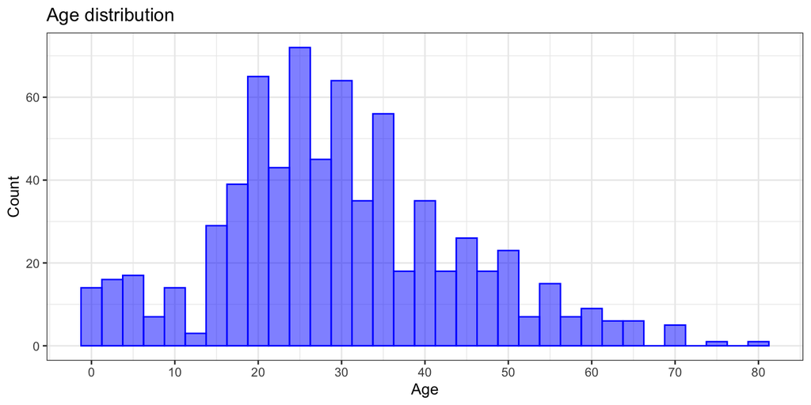

```r
ggplot(titanic,
       aes(x = Age)) +
    geom_histogram(binwidth = 2.5, fill = "blue", color = "blue", alpha = .5) +
    scale_x_continuous(breaks = scales::pretty_breaks(n = 10)) +
    theme_bw() +
    ggtitle("Age distribution") +
    xlab("Age") +
    ylab("Count")
```

It is skewed to the right and there might be outliers.

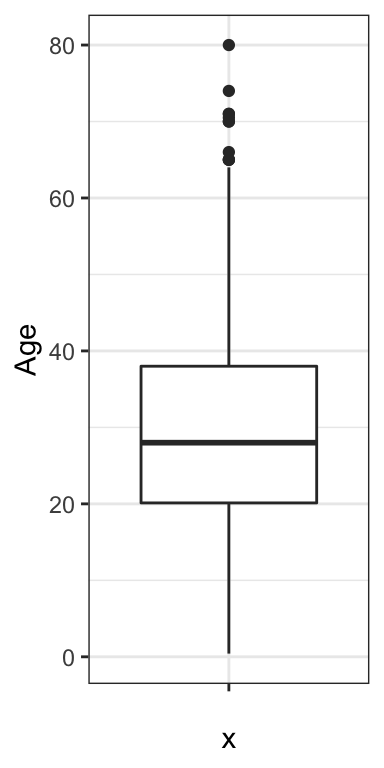

```r
ggplot(titanic) +
  aes(x = "", y = Age) +
  geom_boxplot() +
  theme_bw()
```

Removing outliers:

```r
quartiles = quantile(titanic$Age, probs = c(.25, .75), na.rm = FALSE)
upper = quartiles[2] + 1.5 * IQR(titanic$Age)
titanic = subset(titanic, titanic$Age <= upper)
```

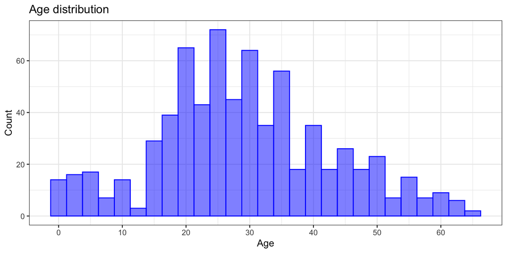

```r
ggplot(titanic,
       aes(x = Age)) +
    geom_histogram(binwidth = 2.5, fill = "blue", color = "blue", alpha = .5) +
    scale_x_continuous(breaks = scales::pretty_breaks(n = 10)) +
    theme_bw() +
    ggtitle("Age distribution") +
    xlab("Age") +
    ylab("Count")
```

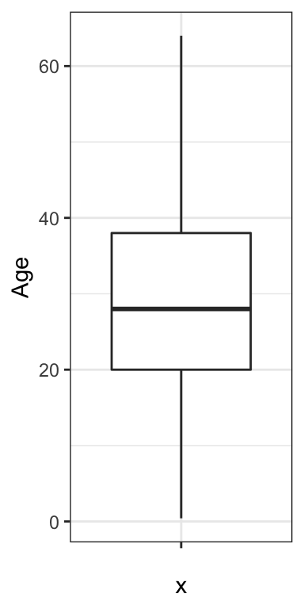

```r
ggplot(titanic) +
  aes(x = "", y = Age) +
  geom_boxplot() +
  theme_bw()
```

## SibSp

Converting to factors:

```r
titanic$SibSp = factor(titanic$SibSp)
```

## Parch

Converting to factors:

```r
titanic$Parch = factor(titanic$Parch)
```

## Ticket

We drop this column as of now.

```r
titanic = subset(titanic, select = -c(Ticket))
```

## Fare

Might be highly correlated to Pclass, we will run tests after this part to decide what we do with it.

Looking at the distribution:

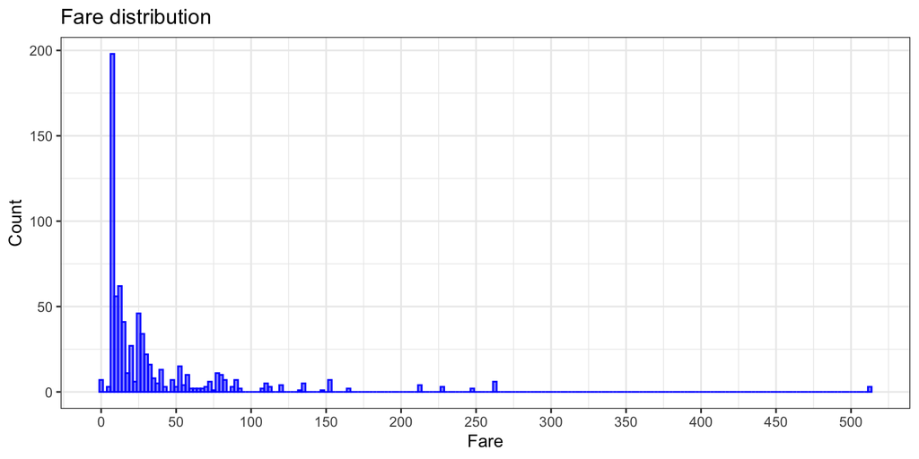

```r
ggplot(titanic,
       aes(x = Fare)) +
    geom_histogram(binwidth = 2.5, fill = "blue", color = "blue", alpha = .5) +
    scale_x_continuous(breaks = scales::pretty_breaks(n = 10)) +
    theme_bw() +
    ggtitle("Fare distribution") +
    xlab("Fare") +
    ylab("Count")
```

It is heavily skewed to the right and there are a lot of outliers.

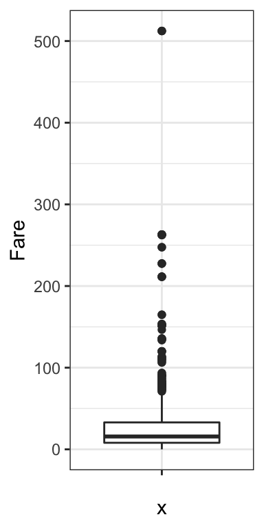

```r
ggplot(titanic) +
  aes(x = "", y = Fare) +
  geom_boxplot() +
  theme_bw()
```

Log transform:

```r
titanic$Fare = log(titanic$Fare + 1)
```

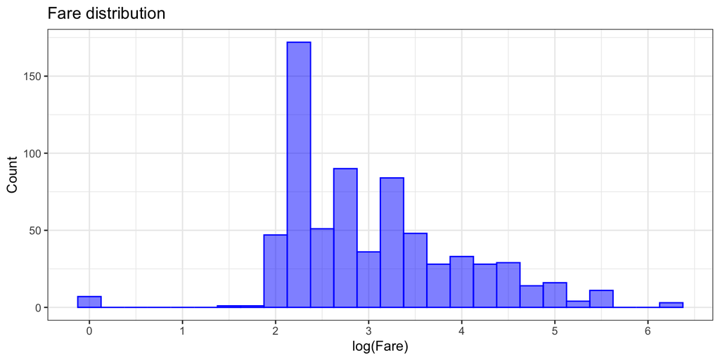

```r
ggplot(titanic,
       aes(x = Fare)) +
    geom_histogram(binwidth = 0.25, fill = "blue", color = "blue", alpha = .5) +
    scale_x_continuous(breaks = scales::pretty_breaks(n = 10)) +
    theme_bw() +
    ggtitle("Fare distribution") +
    xlab("log(Fare)") +
    ylab("Count")
```

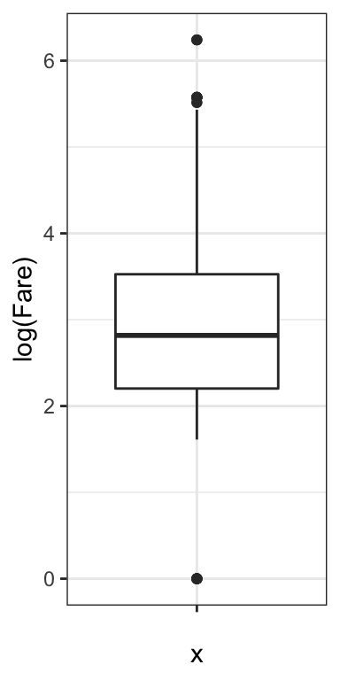

```r
ggplot(titanic) +
  aes(x = "", y = Fare) +
  geom_boxplot() +
  theme_bw() +
  ylab("log(Fare)")
```

Removing outliers:

```r
quartiles = quantile(titanic$Fare, probs = c(.25, .75), na.rm = FALSE)
iqr = IQR(titanic$Fare)
lower = quartiles[1] - 1.5 * iqr
upper = quartiles[2] + 1.5 * iqr
titanic = subset(titanic, titanic$Fare >= lower & titanic$Fare <= upper)
```

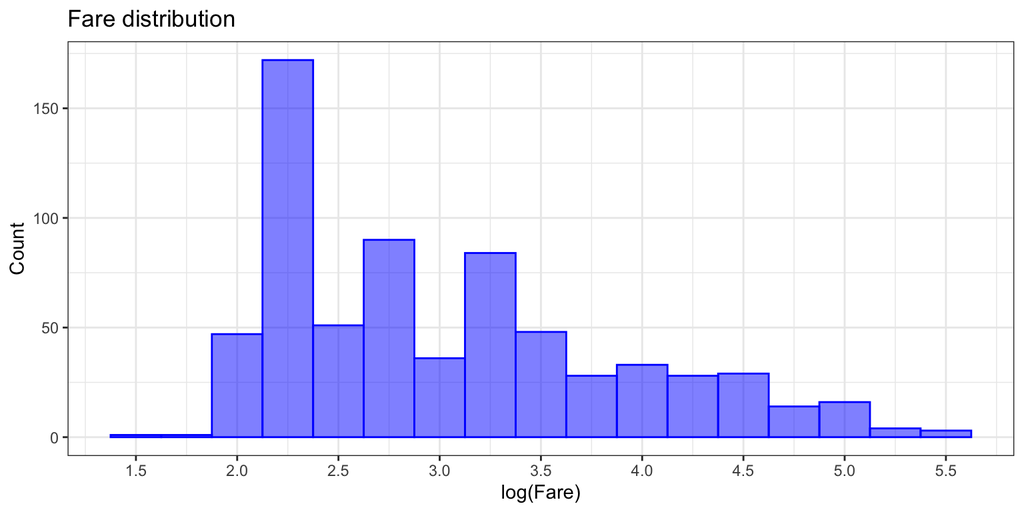

```r
ggplot(titanic,
       aes(x = Fare)) +
    geom_histogram(binwidth = 0.25, fill = "blue", color = "blue", alpha = .5) +
    scale_x_continuous(breaks = scales::pretty_breaks(n = 10)) +
    theme_bw() +
    ggtitle("Fare distribution") +
    xlab("log(Fare)") +
    ylab("Count")
```

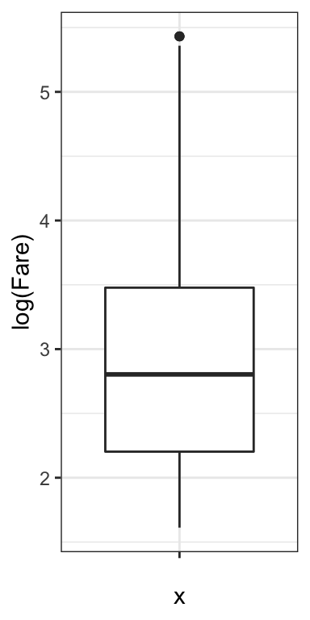

```r
ggplot(titanic) +
  aes(x = "", y = Fare) +
  geom_boxplot() +
  theme_bw() +
  ylab("log(Fare)")
```

## Cabin

We drop this column as of now.

```r
titanic = subset(titanic, select = -c(Cabin))
```

## Embarked

Dropping rows with blank values and converting to factor.

```r
titanic$Embarked[titanic$Embarked == ""] = NA
titanic = titanic[complete.cases(titanic[, c('Embarked')]), ]
titanic$Embarked = factor(titanic$Embarked)
```

# Cleaned data set

```r
head(titanic)
```

```
##   PassengerId Survived Pclass Sex Age SibSp Parch     Fare Embarked
## 1           1        0      3   M  22     1     0 2.110213        S
## 2           2        1      1   F  38     1     0 4.280593        C
## 3           3        1      3   F  26     0     0 2.188856        S
## 4           4        1      1   F  35     1     0 3.990834        S
## 5           5        0      3   M  35     0     0 2.202765        S
## 7           7        0      1   M  54     0     0 3.967694        S
```

```r
summary(titanic)
```

```
##   PassengerId    Survived Pclass  Sex          Age        SibSp   Parch
##  Min.   :  1.0   0:405    1:164   F:253   Min.   : 0.42   0:447   0:501
##  1st Qu.:224.0   1:278    2:171   M:430   1st Qu.:20.00   1:181   1:105
##  Median :448.0            3:348           Median :28.00   2: 23   2: 63
##  Mean   :450.5                            Mean   :28.91   3:  9   3:  5
##  3rd Qu.:677.5                            3rd Qu.:37.00   4: 18   4:  3
##  Max.   :891.0                            Max.   :64.00   5:  5   5:  5
##                                                                   6:  1
##       Fare       Embarked
##  Min.   :1.612   C:120
##  1st Qu.:2.203   Q: 26
##  Median :2.803   S:537
##  Mean   :3.025
##  3rd Qu.:3.474
##  Max.   :5.432
##
```

```r
n = nrow(titanic)
nrow(titanic)
```

```
## [1] 683
```

We still have too many rows to comply with the instructions’ limit of 500. Let’s delete some randomly:

```r
titanic = titanic[-sample(1:nrow(titanic), n - 500), ]
summary(titanic)
```

```
##   PassengerId    Survived Pclass  Sex          Age        SibSp   Parch
##  Min.   :  1.0   0:295    1:110   F:190   Min.   : 0.42   0:330   0:368
##  1st Qu.:227.5   1:205    2:133   M:310   1st Qu.:20.00   1:131   1: 76
##  Median :452.0            3:257           Median :28.00   2: 16   2: 44
##  Mean   :454.3                            Mean   :28.53   3:  7   3:  4
##  3rd Qu.:671.8                            3rd Qu.:37.00   4: 13   4:  3
##  Max.   :890.0                            Max.   :64.00   5:  3   5:  4
##                                                                   6:  1
##       Fare       Embarked
##  Min.   :1.612   C: 89
##  1st Qu.:2.203   Q: 21
##  Median :2.738   S:390
##  Mean   :2.988
##  3rd Qu.:3.436
##  Max.   :5.432
##
```

```r
nrow(titanic)
```

```
## [1] 500
```

# Building the model

```r
mdl = glm(
  Survived ~ Pclass + Sex + Age + SibSp + Parch + Fare + Embarked,
  family = binomial,
  data = titanic
)
```

# Checking logistic regression assumptions

## Dependent variable is binary

```r
table(titanic$Survived)
```

```
##
##   0   1
## 295 205
```

TRUE

## Observations are independent of one another

This is hard to say as we don’t have a way of testing it.  
We assume that it is true.

## Little or no multicollinearity among the independent variables

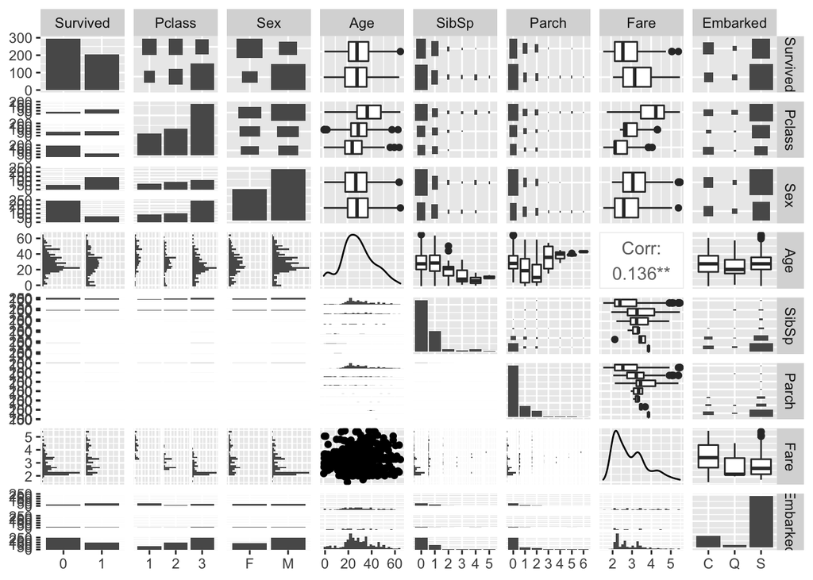

```r
ggpairs(subset(titanic, select = -c(PassengerId)))
```

Looks OK.

## Independent variables are linearly associated with the log odds of the outcome

```r
# We run it on continuous predictors only
continuous_predictors = subset(titanic, select = c(Age, Fare))
predictors_names = colnames(continuous_predictors)

probabilities = predict(mdl, type = "response")

continuous_predictors = continuous_predictors %>%
  mutate(logit = log(probabilities / (1 - probabilities))) %>%
  gather(key = "predictors", value = "predictor.value",-logit)
```

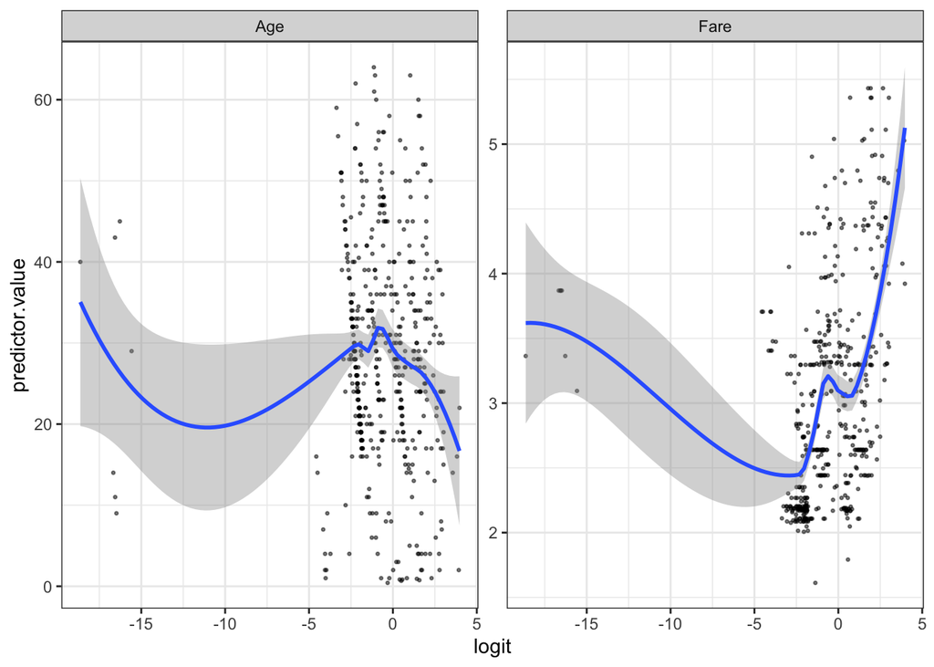

```r
ggplot(continuous_predictors, aes(logit, predictor.value))+
  geom_point(size = 0.5, alpha = 0.5) +
  geom_smooth(method = "loess") +
  theme_bw() +
  facet_wrap(~predictors, scales = "free_y")
```

Not at all, maybe we should remove these variables from the model.

```r
mdl = glm(
  Survived ~ Pclass + Sex + SibSp + Parch + Embarked,
  family = binomial,
  data = titanic
)
```

## Enough samples

The rule of thumb is 10 cases with the least frequent outcome for each independent variable in the model. We need 10 x 5 = 50 for the least frequent outcome.

```r
table(titanic$Survived)
```

```
##
##   0   1
## 295 205
```

TRUE

# Evaluating the model

```r
wald.test(b = coef(mdl), Sigma = vcov(mdl), Terms = 2:6)
```

```
## Wald test:
## ----------
##
## Chi-squared test:
## X2 = 113.3, df = 5, P(> X2) = 0.0
```

Reject $H_0$ since $\text{overall p-value} = 0.0 ≤ \alpha = 0.05$.  
We have significant evidence at the $\alpha = 0.05$ level that at least one $\beta_i ≠ 0$.

```r
summary(mdl)
```

```
##
## Call:
## glm(formula = Survived ~ Pclass + Sex + SibSp + Parch + Embarked,
##     family = binomial, data = titanic)
##
## Deviance Residuals:
##     Min       1Q   Median       3Q      Max
## -2.4413  -0.7349  -0.4624   0.6956   2.1782
##
## Coefficients:
##              Estimate Std. Error z value Pr(>|z|)
## (Intercept)    2.4329     0.3851   6.317 2.66e-10 ***
## Pclass2       -0.6893     0.3333  -2.068   0.0386 *
## Pclass3       -1.6999     0.3132  -5.428 5.70e-08 ***
## SexM          -2.4669     0.2519  -9.793  < 2e-16 ***
## SibSp1        -0.0925     0.2834  -0.326   0.7441
## SibSp2        -0.3023     0.6497  -0.465   0.6417
## SibSp3        -1.5755     0.9436  -1.670   0.0950 .
## SibSp4        -2.6436     1.1884  -2.225   0.0261 *
## SibSp5       -15.4196  1385.3779  -0.011   0.9911
## Parch1         0.7029     0.3569   1.969   0.0489 *
## Parch2         1.0354     0.4667   2.218   0.0265 *
## Parch3        -0.1946     1.2113  -0.161   0.8723
## Parch4       -16.1484  1197.2876  -0.013   0.9892
## Parch5        -1.3541     1.1859  -1.142   0.2535
## Parch6       -16.7587  2399.5447  -0.007   0.9944
## EmbarkedQ     -0.3854     0.6300  -0.612   0.5407
## EmbarkedS     -0.4479     0.3127  -1.432   0.1521
## ---
## Signif. codes:  0 '***' 0.001 '**' 0.01 '*' 0.05 '.' 0.1 ' ' 1
##
## (Dispersion parameter for binomial family taken to be 1)
##
##     Null deviance: 676.86  on 499  degrees of freedom
## Residual deviance: 462.83  on 483  degrees of freedom
## AIC: 496.83
##
## Number of Fisher Scoring iterations: 15
```

We are unable to say that all the other coefficients are significant.

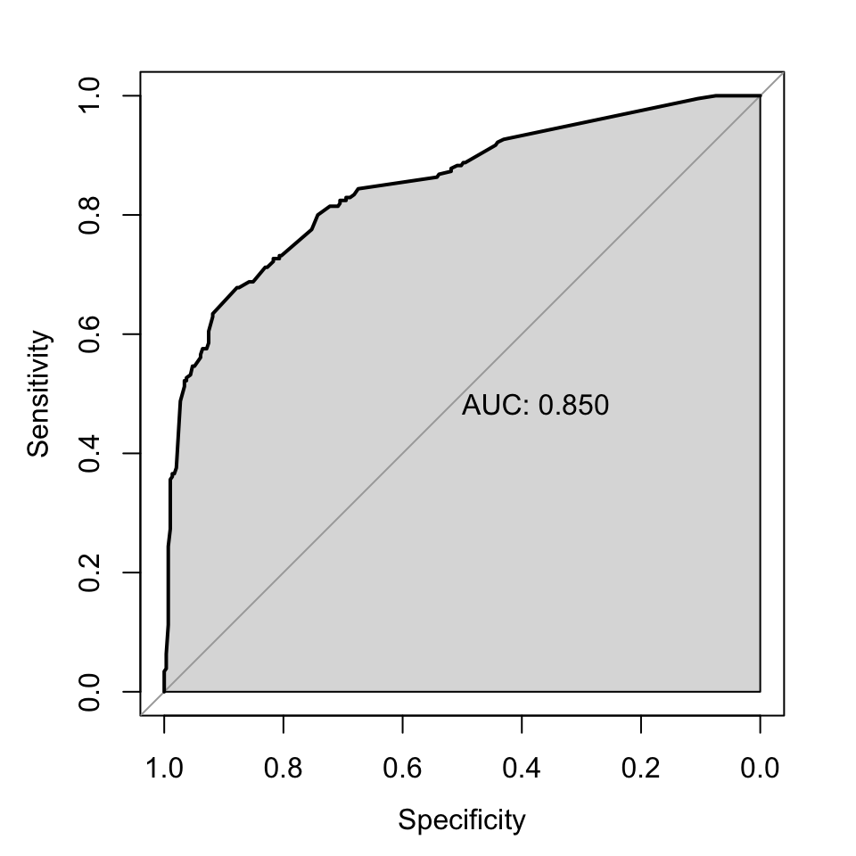

```r
titanic$prob = predict(mdl, type = c("response"))
plot(roc(Survived ~ prob, data = titanic),
     print.auc = TRUE,
     auc.polygon = TRUE)
```

The c-statistic of the model is 0.848 (value may differ slightly because of the random sampling of the data to have 500 observations).

```r
titanic$pred = ifelse(titanic$prob >= 0.50, 1, 0)

# Confusion matrix
table(titanic$Survived, titanic$pred)
```

```
##
##       0   1
##   0 253  42
##   1  64 141
```

```r
error = mean(titanic$Survived != titanic$pred)
paste("Accuracy:", round(1 - error, 4))
```

```
## [1] "Accuracy: 0.788"
```

**We get an accuracy of 79% with this model when choosing a cutoff of 0.5**  
(value may differ slightly because of the random sampling of the data to have 500 observations)

# Second model with only Pclass and Sex as predictors

```r
mdl_2 = glm(
  Survived ~ Pclass + Sex,
  family = binomial,
  data = titanic
)
```

```r
wald.test(b = coef(mdl_2), Sigma = vcov(mdl_2), Terms = 2:3)
```

```
## Wald test:
## ----------
##
## Chi-squared test:
## X2 = 49.0, df = 2, P(> X2) = 2.2e-11
```

```r
summary(mdl_2)
```

```
##
## Call:
## glm(formula = Survived ~ Pclass + Sex, family = binomial, data = titanic)
##
## Deviance Residuals:
##     Min       1Q   Median       3Q      Max
## -2.1617  -0.7993  -0.4709   0.6523   2.1234
##
## Coefficients:
##             Estimate Std. Error z value Pr(>|z|)
## (Intercept)   2.2348     0.2920   7.655 1.94e-14 ***
## Pclass2      -0.7954     0.3088  -2.576     0.01 *
## Pclass3      -1.9618     0.2913  -6.736 1.63e-11 ***
## SexM         -2.4165     0.2355 -10.260  < 2e-16 ***
## ---
## Signif. codes:  0 '***' 0.001 '**' 0.01 '*' 0.05 '.' 0.1 ' ' 1
##
## (Dispersion parameter for binomial family taken to be 1)
##
##     Null deviance: 676.86  on 499  degrees of freedom
## Residual deviance: 487.58  on 496  degrees of freedom
## AIC: 495.58
##
## Number of Fisher Scoring iterations: 4
```

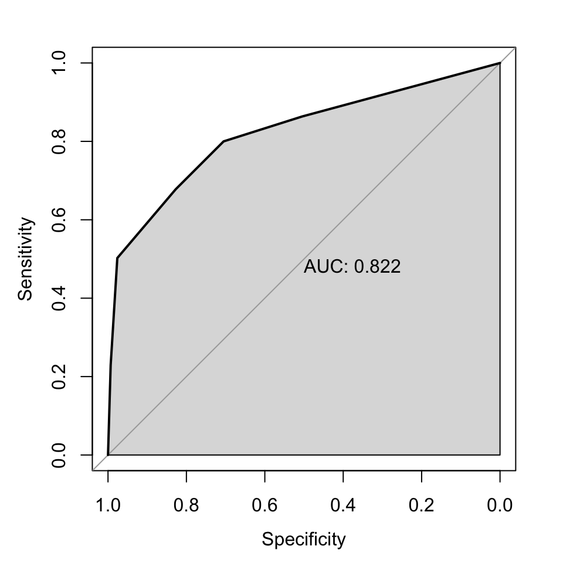

```r
titanic$prob_2 = predict(mdl_2, type = c("response"))
plot(roc(Survived ~ prob_2, data = titanic),
     print.auc = TRUE,
     auc.polygon = TRUE)
```

The c-statistic of the model is 0.821. (value may differ slightly because of the random sampling of the data to have 500 observations)

```r
titanic$pred_2 = ifelse(titanic$prob_2 >= 0.50, 1, 0)

# Confusion matrix
table(titanic$Survived, titanic$pred_2)
```

```
##
##       0   1
##   0 244  51
##   1  66 139
```

```r
error = mean(titanic$Survived != titanic$pred_2)
paste("Accuracy:", round(1 - error, 4))
```

```
## [1] "Accuracy: 0.766"
```

# Exporting the final dataset

```r
write.csv(subset(titanic, select = c(Pclass, Sex, SibSp, Parch, Embarked, Survived)), "project_benoit_clemenceau.csv", row.names = TRUE)
```